# Predicting the odds of a bank customer accepting a new campaign offer

In this study we propose the development of a predictive model according to the Industry Standard Process for Data Mining (CRISP-DM) methodology, to help our client, a Portuguese bank, to maximize the performance of its future telemarketing campaigns. This model was developed using Data Mining (DM) techniques, and allowed us to analyze a set of data, collected between 2008 and 2013 , with a total of 52,944 records. The goal was to prove the relevance of applying a set of machine learning techniques, in order to provide better results in a future telemarketing campaign and if possible with lower costs associated with it.

### Importing libraries

```python
import pandas as pd
import numpy as np
import seaborn as sns
import matplotlib.pyplot as plt
from sklearn.ensemble import IsolationForest
```

### Data Quality

Starting with the quality of the data, it was possible to realize that it is good since a large part of the data is already treated, an example of this is the fact that there are no null fields. Or that there are not, in the same column, for example, 2 'names', where it is obvious that the difference between them is a spelling error. This way, there will be no need for a previous phase of processing them.

### Exploratory Data Analysis

Here we identified if the data had some bias or if there was some groups of people that said "Yes" or "No" to past campaigns more often than other groups and therefore we could potencialy do some clusters on them. This was also important to check if the data had some outliers that potencialy needed to be removed. Bellow will be some of the plots that we did in order to identify those issues.

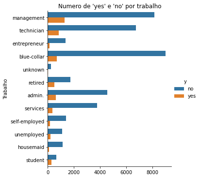

```python
ax=sns.catplot(data= df1,
            y="job",
            kind="count",
            hue ="y")
ax.set(xlabel='', ylabel='Trabalho', title ="Numero de 'yes' e 'no' por trabalho")
```

[output not shown]

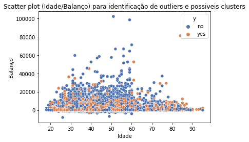

```python
data_2 = df1.loc[(df1.job !="unknown")]

ax=sns.scatterplot(data=data_2,
                x="age",
                y="balance",
                hue="y",
                #style="education"
                palette="deep"
               )
ax.set(xlabel='Idade', ylabel='Balanço', title ="Scatter plot (Idade/Balanço) para identificação de outliers e possiveis clusters")
```

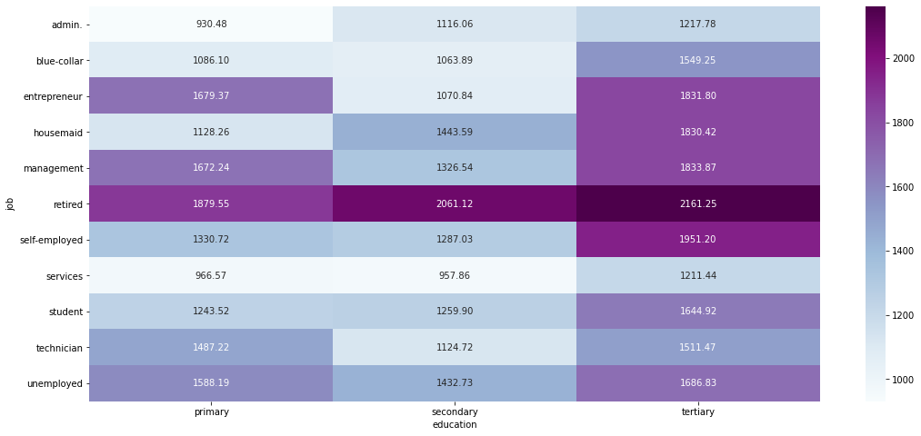

```python
dataset_t = df1.loc[(df1.education !="unknown" )
                    & (df1.job !="unknown")]
((df1["education"]=="unknown") | (df1["job"]=="unknown")).value_counts()

mapacalor = dataset_t.pivot_table(values='balance', index="job",columns="education")
plt.figure(figsize=(18, 8))
sns.heatmap(mapacalor, annot=True,fmt='.2f',cmap="BuPu")
```

### Identifing Ouliers

More libraries were added depending what we needed from sklearn in the future, but in the beginning, we started by identifing the outliers of the data in order to get beter results in the Machine learning part.

```python
model=IsolationForest(n_estimators=50, max_samples='auto', contamination=float(0.001),max_features=1.0)
model.fit(df1[['balance']])
df1['anomaly_b']=model.predict(df1[['balance']])
```

[output not shown]

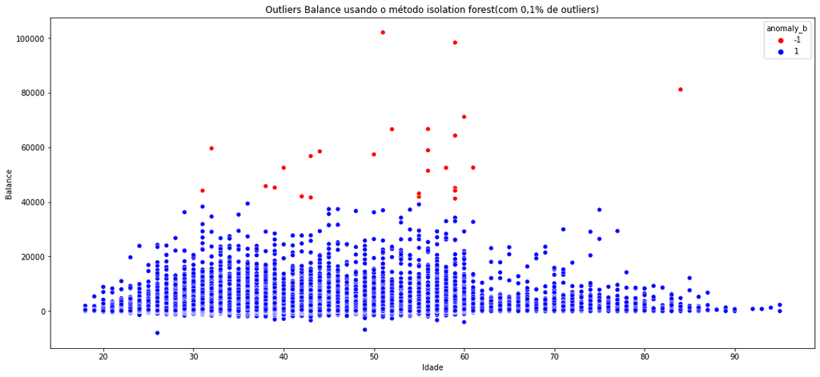

```python
plt.figure(figsize=(18, 8))
ax=sns.scatterplot(data=df1,
               x="age",
               y="balance",
               hue="anomaly_b", palette=['red','blue']
                  )
ax.set(xlabel='Idade', ylabel='Balance', title ="Outliers Balance usando o método isolation forest(com 0,1% de outliers)")
```

We did this to multiply columns until we found all the outliers that we though should be removed and proceeded to remove them.

### Classification

● '17 - y': because it is the target variable of the prototype and classification techniques;

● '12 - duration': because this data is only known when the call ends, and the operator needs to know the result of the prediction, in the course of the call.

```
Logistic Regression: ROC AUC=0.670
Arvore_decisao: ROC AUC=0.602
SGDClassifier: ROC AUC=0.699
LinearDiscriminantAnalysis: ROC AUC=0.718
QuadraticDiscriminantAnalysis: ROC AUC=0.712
Naive Bayes: ROC AUC=0.701
BernoulliNB: ROC AUC=0.701
Neural network MLPClassifier: ROC AUC=0.662
```

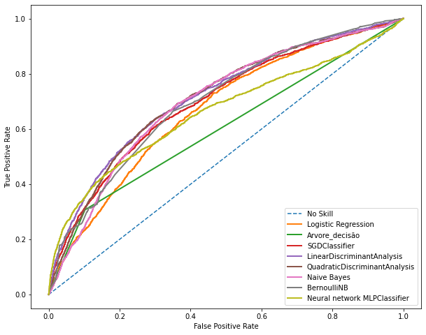

```python
print('Logistic Regression: ROC AUC=%.3f' % (roc_score_0))
print('Arvore_decisao: ROC AUC=%.3f' % (roc_score_1))
print('SGDClassifier: ROC AUC=%.3f' % (roc_score_2))
print('LinearDiscriminantAnalysis: ROC AUC=%.3f' % (roc_score_3))
print('QuadraticDiscriminantAnalysis: ROC AUC=%.3f' % (roc_score_4))
print('Naive Bayes: ROC AUC=%.3f' % (roc_score_5))
print('BernoulliNB: ROC AUC=%.3f' % (roc_score_6))
print('Neural network MLPClassifier: ROC AUC=%.3f' % (roc_score_7))
# calculate roc curves
plt.figure(figsize=(10, 8))

# plot the roc curve for the model
plt.plot(ns_fpr, ns_tpr, linestyle='--', label='No Skill')
plt.plot(falsep_0, truep_0, marker=',', label='Logistic Regression',linewidth=2)
plt.plot(falsep_1, truep_1, marker=',', label='Arvore_decisão',linewidth=2)
plt.plot(falsep_2, truep_2, marker=',', label='SGDClassifier',linewidth=2)
plt.plot(falsep_3, truep_3, marker=',', label='LinearDiscriminantAnalysis',linewidth=2)
plt.plot(falsep_4, truep_4, marker=',', label='QuadraticDiscriminantAnalysis',linewidth=2)
plt.plot(falsep_5, truep_5, marker=',', label='Naive Bayes',linewidth=2)
plt.plot(falsep_6, truep_6, marker=',', label='BernoulliNB',linewidth=2)
plt.plot(falsep_7, truep_7, marker=',', label='Neural network MLPClassifier',linewidth=2)
# axis labels

plt.xlabel('False Positive Rate')
plt.ylabel('True Positive Rate')
# show the legend
plt.legend(loc="lower right")
# show the plot
plt.show()
```

The model that gave the best result was LinearDiscriminantAnalysis, with a ROC of 0.718

### Streamlit

If you wanna check our streamlit implementation of this project, check out my [github project](https://github.com/LopesJos/ML_project). We also did a [youtube video](https://www.youtube.com/watch?v=AZDSOEW-gD4) explaining what we did in streamlit. [The video](https://www.youtube.com/watch?v=AZDSOEW-gD4) is narrated in portuguese.